# Assigment 2 : NOAA Storm Database Analysis Report

# Synopsis

Storms and other severe weather events can cause both public health and economic problems for communities and municipalities. Many severe events can result in fatalities, injuries, and property damage, and preventing such outcomes to the extent possible is a key concern.

In this analysis it was explored the U.S. National Oceanic and Atmospheric Administration’s (NOAA) storm database and reported:

- The top 10 types of events across United States which are more harmful to population health.
- The top 10 types of events across United States which have the greatest economic consequences.

# Data Processing

### Data information

The data for this assignment come in the form of a comma-separated-value file compressed via the bzip2 algorithm to reduce its size. You can download the file from the course web site:

Storm Data [47Mb](https://d396qusza40orc.cloudfront.net/repdata%2Fdata%2FStormData.csv.bz2) There is also some documentation of the database available. Here you will find how some of the variables are constructed/defined.

- National Weather Service Storm [Data Documentation](https://d396qusza40orc.cloudfront.net/repdata%2Fpeer2_doc%2Fpd01016005curr.pdf)
- National Climatic Data Center Storm Events [FAQ](https://d396qusza40orc.cloudfront.net/repdata%2Fpeer2_doc%2FNCDC%20Storm%20Events-FAQ%20Page.pdf)

The events in the database start in the year 1950 and end in November 2011. In the earlier years of the database there are generally fewer events recorded, most likely due to a lack of good records. More recent years should be considered more complete.

### Data loading and pre-processing

The function below was used to download, extract and load the data.

```r
loadData <- function()
{
        URL <- "https://d396qusza40orc.cloudfront.net/repdata%2Fdata%2FStormData.csv.bz2"
        destfile <- "dataset.csv.bz2"

        if (!file.exists(destfile))  # Check if the file already exists
        {
                download.file(URL, destfile,"curl") #Download data
        }
        data <- read.csv(destfile)   # load the data
}
```

Calling the function:

```r
data <- loadData()
```

##### Some information about the data loaded:

Colunms names:

```r
names(data)
```

```
##  [1] "STATE__"    "BGN_DATE"   "BGN_TIME"   "TIME_ZONE"  "COUNTY"
##  [6] "COUNTYNAME" "STATE"      "EVTYPE"     "BGN_RANGE"  "BGN_AZI"
## [11] "BGN_LOCATI" "END_DATE"   "END_TIME"   "COUNTY_END" "COUNTYENDN"
## [16] "END_RANGE"  "END_AZI"    "END_LOCATI" "LENGTH"     "WIDTH"
## [21] "F"          "MAG"        "FATALITIES" "INJURIES"   "PROPDMG"
## [26] "PROPDMGEXP" "CROPDMG"    "CROPDMGEXP" "WFO"        "STATEOFFIC"
## [31] "ZONENAMES"  "LATITUDE"   "LONGITUDE"  "LATITUDE_E" "LONGITUDE_"
## [36] "REMARKS"    "REFNUM"
```

Number of rows:

```r
nrow(data)
```

```
## [1] 902297
```

#### Some packages that might be needed to reproduce this analysis:

```r
if (!("ggplot2" %in% rownames(installed.packages())))
        install.packages("ggplot2")

library(ggplot2)
library(grid)

if (!("gridExtra" %in% rownames(installed.packages())))
        install.packages("gridExtra")

library(gridExtra)
```

### Results

This data analysis report addresses the following questions:

#### 1) Across the United States, which types of events (as indicated in the EVTYPE variable) are most harmful with respect to population health?

To answer this question there were considered the variables 1) number of fatalities and 2) number of injuries for each type of event in the data set. The first step was: * Aggregating the total of fatalities and injuries by type of event:

```r
fatalities <- aggregate(FATALITIES ~ EVTYPE, data = data, FUN = sum)
injuries   <- aggregate(INJURIES   ~ EVTYPE, data = data, FUN = sum)
```

- Secondly, it was selected from the aggregated data the top 10 events that cause most fatalities and the top 10 that cause most injuries:

```r
# Sorting by number of fatalities and removing the top 10
top10Fatal <- head(fatalities[ order(-fatalities[,2]), ],10)

# Sorting by number of injuries and removing the top 10
top10Injur <- head(injuries[ order(-injuries[,2]), ],10)
```

- Thirdly, relevel the FATALITIES by EVTYPE, so that the plot starts with the lower fatalities and the same applyied to the INJURIES aggregated data.

```r
# bars and ends with the higher ones.
top10Fatal$EVTYPE <- factor(top10Fatal$EVTYPE, levels=top10Fatal[order(top10Fatal$FATALITIES),"EVTYPE"])

top10Injur$EVTYPE <- factor(top10Injur$EVTYPE, levels=top10Injur[order(top10Injur$INJURIES),"EVTYPE"])
```

- Finally, the plots were drawn:

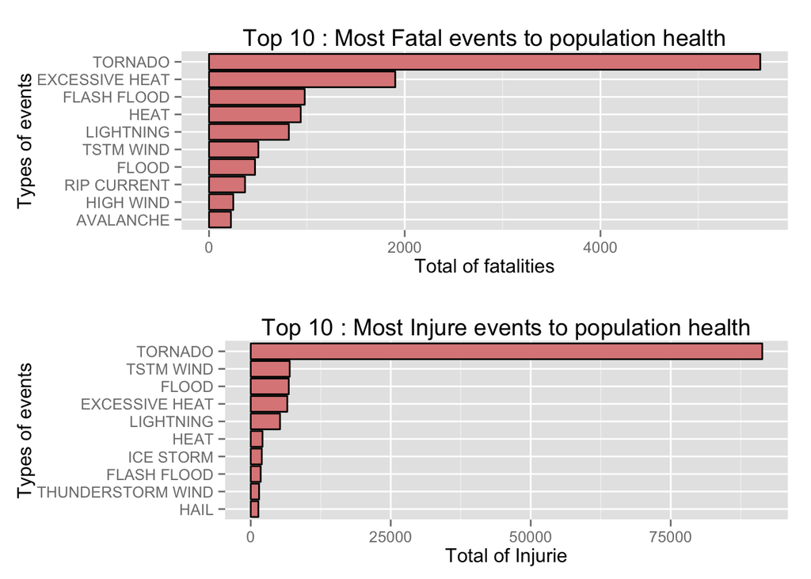

```r
# Draw the plots
fatalPlot <- ggplot(data=top10Fatal, aes(x=EVTYPE, y=FATALITIES, fill=EVTYPE)) +
             geom_bar(colour="black", fill="#DD8888",stat="identity") +
             guides(fill=FALSE) +
             xlab("Types of events") + ylab("Total of fatalities") +
             ggtitle("Top 10 : Most Fatal events to population health") + coord_flip()


injurPlot <- ggplot(data=top10Injur, aes(x=EVTYPE, y=INJURIES, fill=EVTYPE)) +
                geom_bar(colour="black", fill="#DD8888",stat="identity") +
                guides(fill=FALSE) +
                xlab("Types of events") + ylab("Total of Injurie") +
                ggtitle("Top 10 : Most Injure events to population health") +        coord_flip()

grid.arrange(fatalPlot, injurPlot, nrow=2)
```

The plots shows the 10 most fatal and injure events to population’s health. As we can see in the plots tornadoes are the main event that causes the majory of fatalities and injuries. Excessive heat and flash flood are the second and third, respectively, most fatal events. TSTM wind and flood are the second and third, respectively, events that causes the most number of injures.

#### 2) Across the United States, which types of events have the greatest economic consequences?

To answer this question, first it is necessary to understand which variables are related with economic consequences. Those variables were identified through the reading of the National [Weather Service Storm Data Documentation](https://d396qusza40orc.cloudfront.net/repdata%2Fpeer2_doc%2Fpd01016005curr.pdf).

As it is stated on the Weather Service Storm Data Documentation:

- PROPDMG Damage. > Property damage estimates should be entered as actual dollar amounts, if a reasonably accurate estimate from an insurance company or other qualified individual is available.
- CROPDMG. > Crop Damage Data. Crop damage information may be obtained from reliable sources

Besides those two variables (**PROPDMG, CROPDMG**), **PROPDMGEXP** and **CROPDMGEXP** are also related with economic consequences. **PROPDMGEXP** and **CROPDMGEXP** are orders of magnitude, which can be understanded as 10^EXP.

Therefore, the original data was subseted into a data with four columns one for each economic consequence variable:

```r
economic <- data[c("EVTYPE","PROPDMG","PROPDMGEXP","CROPDMG","CROPDMGEXP")]
```

By analyising the types of orders of magnitude used for the Property damage,

```r
unique(economic$PROPDMGEXP)
```

```
##  [1] K M   B m + 0 5 6 ? 4 2 3 h 7 H - 1 8
## Levels:  - ? + 0 1 2 3 4 5 6 7 8 B h H K m M
```

and for the Crop damage,

```r
unique(economic$CROPDMGEXP)
```

```
## [1]   M K m B ? 0 k 2
## Levels:  ? 0 2 B k K m M
```

it was extrapolated that : * H or h = 2 (hundred = 10^2) * K or k = 3 (thousand = 10^3) * M or m = 6 (million = 10^6) * B or b = 9 (billion = 10^9)

and symbols ‘+’, ‘-’ and ‘?’ as meaningless information.

The Property damage event can then be calculated as **PROPDMG * 10 ^ (PROPDMGEXP)** and the crop damage as **CROPDMG * 10 ^(CROPDMGEXP)**

The below function will transform the rows with “Hh”,“Kk”,“Mm”,“Bb”,“+-?” and “” symbols into “2”, “3”,“6”,“9”, “0” and “0” values, respectively. Thus, this new values will be used to calculate the total economical consequences of a given event.

```r
transfData <- function(col)
{
        replace <- c("2","3","6","9","0")
        regex   <- c("[Hh]","[Kk]","[Mm]","[Bb]","[+-/?]")
        size <- length(replace)
        for (i in 1:size)
        {
                col <- sub(regex[i], replace[i],col)
        }
        col[col == ""] <- "0" # Removing empty space
        col <- as.numeric(col) # Converting col values into numeric ones
        col
}
```

Changing the old symbols of the colunm **PROPDMGEXP**:

```r
#Removing simbols for values
economic$PROPDMGEXP = transfData(economic$PROPDMGEXP)

# New values
unique(economic$PROPDMGEXP) # "3" "6" "0" "9" "5" "4" "2" "7" "1" "8""
```

```
##  [1] 3 6 0 9 5 4 2 7 1 8
```

Changing the old symbols of the colunm **CROPDMGEXP**:

```r
#Removing simbols for values
economic$CROPDMGEXP= transfData(economic$CROPDMGEXP)

# New values
unique(economic$CROPDMGEXP) #[1] "0" "6" "3" "9" "2"
```

```
## [1] 0 6 3 9 2
```

In order to calculate the total economical consequence of a given event the following formula was used: **PROPDMG * 10 ^ PROPDMGEXP + CROPDMG * 10 ^ CROPDMGEXP**

```r
economic$EconomicLoss <- economic$PROPDMG * 10 ^ economic$PROPDMGEXP + economic$CROPDMG * 10 ^ economic$CROPDMGEXP
```

After calculating the economical consequence for each event, stored in a new colunm, the new column was aggregated along with the types of events:

```r
economicLoss <- aggregate(EconomicLoss ~ EVTYPE, data = economic, FUN = sum)
```

It was selected from the aggregated data the top 10 events responsible for the most economical damage:

```r
top10EconomicLoss <- head(economicLoss[ order(-economicLoss[,2]), ],10)

top10EconomicLoss$EVTYPE <- factor(top10EconomicLoss$EVTYPE, levels=top10EconomicLoss[order(top10EconomicLoss$EconomicLoss),"EVTYPE"])
```

Finally, the plot was drawn with the top 10 types of events:

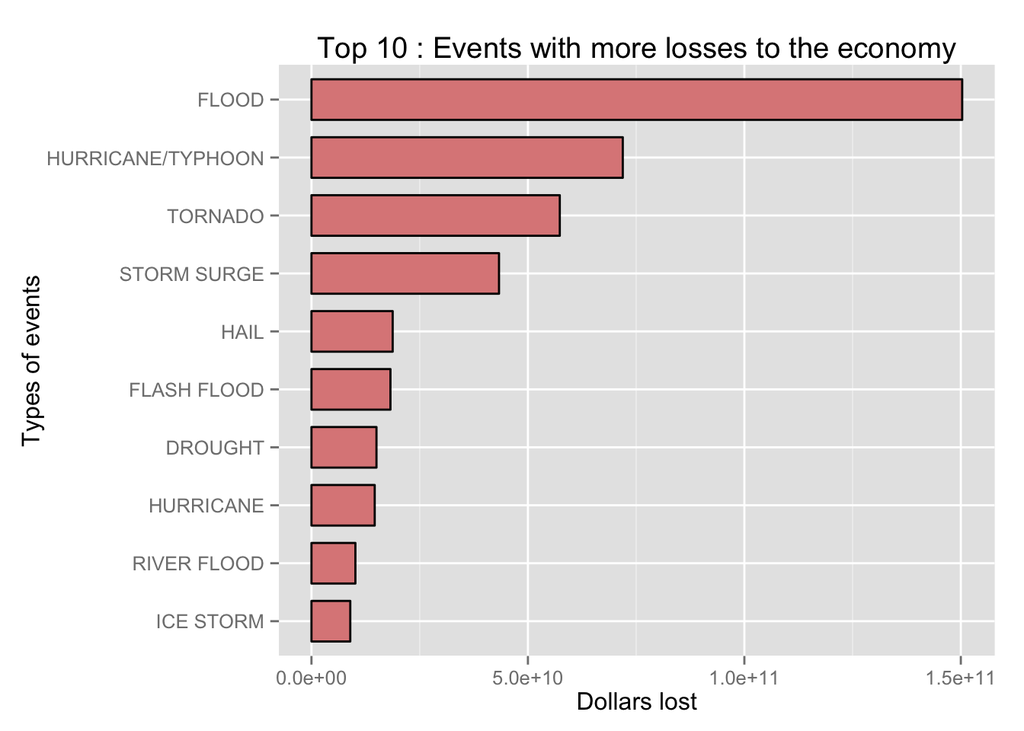

```r
ggplot(data=top10EconomicLoss, aes(x=EVTYPE, y=EconomicLoss, fill=EVTYPE)) +
        geom_bar(colour="black", fill="#DD8888", width=.7,stat="identity") +
        guides(fill=FALSE) +
        xlab("Types of events") + ylab("Dollars lost") +
        ggtitle("Top 10 : Events with more losses to the economy") + coord_flip()
```

As it can be seen on the produced plot, flood is by far the event that causes the most economical damage, 150319678257 dollars in total, followed by 71913712800 dollars caused by Hurricanes and Typhoons and 57362333946 dollars caused by tornados. Furturmore, the top 10 are responsible for a total of 408668825938 dollars, which correspond to:

```r
sum(top10EconomicLoss$EconomicLoss) / sum(economicLoss$EconomicLoss)
```

```
## [1] 0.8561574
```

85.6% of the dollars spend with all types of events.

Considering all the events floods are responsible for:

```r
max(economicLoss$EconomicLoss) / sum(economicLoss$EconomicLoss)
```

```
## [1] 0.3149183
```

31.49% of the damages.